# HW-Classification

Sena Çiftçi

2025-12-30

## Credit Data

This assignment is related with Credit Data. As the first step, the provided dataset must be imported to R.

```r
# libraries to be used
library(tidyverse)
library(GGally)
library(rpart)
library(rpart.plot)
library(cvms)
library(tibble)

# import the data set
credit <- read_csv(file="credit.csv")

# convert to data frame
credit <- as.data.frame(credit)

dim(credit)
```

```
## [1] 28630    12
```

```r
colnames(credit)
```

```
##  [1] "age"                 "income"              "home_ownership"
##  [4] "emp_length"          "loan_intent"         "loan_grade"
##  [7] "loan_amnt"           "loan_int_rate"       "loan_status"
## [10] "loan_percent_income" "default_before"      "cred_hist_length"
```

```r
str(credit)
```

```
## 'data.frame':    28630 obs. of  12 variables:
##  $ age                : num  22 21 25 23 24 21 26 24 24 21 ...
##  $ income             : num  59000 9600 9600 65500 54400 ...
##  $ home_ownership     : chr  "RENT" "OWN" "MORTGAGE" "RENT" ...
##  $ emp_length         : num  123 5 1 4 8 2 8 5 8 6 ...
##  $ loan_intent        : chr  "PERSONAL" "EDUCATION" "MEDICAL" "MEDICAL" ...
##  $ loan_grade         : chr  "D" "B" "C" "C" ...
##  $ loan_amnt          : num  35000 1000 5500 35000 35000 2500 35000 35000 35000 1600 ...
##  $ loan_int_rate      : num  16 11.1 12.9 15.2 14.3 ...
##  $ loan_status        : num  1 0 1 1 1 1 1 1 1 1 ...
##  $ loan_percent_income: num  0.59 0.1 0.57 0.53 0.55 0.25 0.45 0.44 0.42 0.16 ...
##  $ default_before     : chr  "Y" "N" "N" "N" ...
##  $ cred_hist_length   : num  3 2 3 2 4 2 3 4 2 3 ...
```

## Variables

person_age: Age  
person_income: Annual Income  
person_home_ownership: Home ownership  
person_emp_length: Employment length (in years)  
loan_intent: Loan intent  
loan_grade: Loan grade  
loan_amnt: Loan amount  
loan_int_rate: Interest rate  
loan_status: Loan status (0 is non default 1 is default)  
loan_percent_income: Percent income  
default_before: Historical default  
cred_hist_length: Credit history length

## First Look: Summary and Glimpse

A first look:

- How many observations?
- How many NAs?
- Categorical Variable Names?
- Tables for Categorical Variables?

```r
summary(credit)
```

```
##       age           income        home_ownership       emp_length
##  Min.   :20.0   Min.   :   4000   Length:28630       Min.   :  0.000
##  1st Qu.:23.0   1st Qu.:  39456   Class :character   1st Qu.:  2.000
##  Median :26.0   Median :  55900   Mode  :character   Median :  4.000
##  Mean   :27.7   Mean   :  66430                      Mean   :  4.787
##  3rd Qu.:30.0   3rd Qu.:  80000                      3rd Qu.:  7.000
##  Max.   :73.0   Max.   :2039784                      Max.   :123.000
##  loan_intent         loan_grade          loan_amnt     loan_int_rate
##  Length:28630       Length:28630       Min.   :  500   Min.   : 5.42
##  Class :character   Class :character   1st Qu.: 5000   1st Qu.: 7.90
##  Mode  :character   Mode  :character   Median : 8000   Median :10.99
##                                        Mean   : 9657   Mean   :11.04
##                                        3rd Qu.:12500   3rd Qu.:13.48
##                                        Max.   :35000   Max.   :23.22
##   loan_status     loan_percent_income default_before     cred_hist_length
##  Min.   :0.0000   Min.   :0.0000      Length:28630       Min.   : 2.000
##  1st Qu.:0.0000   1st Qu.:0.0900      Class :character   1st Qu.: 3.000
##  Median :0.0000   Median :0.1500      Mode  :character   Median : 4.000
##  Mean   :0.2167   Mean   :0.1695                         Mean   : 5.791
##  3rd Qu.:0.0000   3rd Qu.:0.2300                         3rd Qu.: 8.000
##  Max.   :1.0000   Max.   :0.8300                         Max.   :30.000
```

```r
glimpse(credit)
```

```
## Rows: 28,630
## Columns: 12
## $ age                 <dbl> 22, 21, 25, 23, 24, 21, 26, 24, 24, 21, 22, 21, 23…
## $ income              <dbl> 59000, 9600, 9600, 65500, 54400, 9900, 77100, 7895…
## $ home_ownership      <chr> "RENT", "OWN", "MORTGAGE", "RENT", "RENT", "OWN", …
## $ emp_length          <dbl> 123, 5, 1, 4, 8, 2, 8, 5, 8, 6, 6, 2, 2, 4, 2, 7, …
## $ loan_intent         <chr> "PERSONAL", "EDUCATION", "MEDICAL", "MEDICAL", "ME…
## $ loan_grade          <chr> "D", "B", "C", "C", "C", "A", "B", "B", "A", "D", …
## $ loan_amnt           <dbl> 35000, 1000, 5500, 35000, 35000, 2500, 35000, 3500…
## $ loan_int_rate       <dbl> 16.02, 11.14, 12.87, 15.23, 14.27, 7.14, 12.42, 11…
## $ loan_status         <dbl> 1, 0, 1, 1, 1, 1, 1, 1, 1, 1, 1, 1, 1, 1, 0, 0, 0,…
## $ loan_percent_income <dbl> 0.59, 0.10, 0.57, 0.53, 0.55, 0.25, 0.45, 0.44, 0.…
## $ default_before      <chr> "Y", "N", "N", "N", "Y", "N", "N", "N", "N", "N", …
## $ cred_hist_length    <dbl> 3, 2, 3, 2, 4, 2, 3, 4, 2, 3, 4, 2, 2, 4, 4, 3, 4,…
```

```r
# How many observations?

nrow(credit)
```

```
## [1] 28630
```

```r
# How many NAs?

colSums(is.na(credit))
```

```
##                 age              income      home_ownership          emp_length
##                   0                   0                   0                   0
##         loan_intent          loan_grade           loan_amnt       loan_int_rate
##                   0                   0                   0                   0
##         loan_status loan_percent_income      default_before    cred_hist_length
##                   0                   0                   0                   0
```

```r
# Numeric variables
credit |>
  select_if(is.numeric) |> # select only numeric columns
  colnames()  # names
```

```
## [1] "age"                 "income"              "emp_length"
## [4] "loan_amnt"           "loan_int_rate"       "loan_status"
## [7] "loan_percent_income" "cred_hist_length"
```

```r
# Character variables
credit |>
  select_if(is.character) |> # select only character columns
  colnames() #names
```

```
## [1] "home_ownership" "loan_intent"    "loan_grade"     "default_before"
```

```r
# Analyze the class imbalance of the loan_status variable

table(credit$loan_status)
```

```
##
##     0     1
## 22427  6203
```

```r
# Meaning the 22427 of the borrowers have successfully repaid the loan (low risk) and the 6203 of the borrowers have not successfully repaid the loan (high risk)

# table of home_ownership

table(credit$home_ownership)
```

```
##
## MORTGAGE    OTHER      OWN     RENT
##    11798       94     2192    14546
```

```r
# more tables
table(credit$loan_intent)
```

```
##
## DEBTCONSOLIDATION         EDUCATION   HOMEIMPROVEMENT           MEDICAL
##              4565              5702              3198              5290
##          PERSONAL           VENTURE
##              4875              5000
```

```r
table(credit$loan_int_rate)
```

```
##
##  5.42  5.79  5.99     6  6.03  6.17  6.39  6.54  6.62  6.76  6.91  6.92  6.99
##   541   374   339    12   415   203    59   246   393   170   256   199   318
##  7.05  7.12  7.14  7.29  7.37   7.4  7.42  7.43  7.49  7.51  7.66  7.68  7.74
##    19     8   320   367    35    67     8    25   625   724   252    89   151
##  7.75  7.88   7.9  7.91     8  8.07  8.32  8.38  8.49  8.59  8.63   8.7  8.88
##    21   624   553    13   189    23    50    18   401   186    36    14   117
##   8.9  8.94  9.01  9.07   9.2  9.25  9.32  9.33  9.38  9.45  9.51  9.62  9.63
##   349   298    10    14    14   107   188    16    19    42     7    99   351
##  9.64  9.67   9.7  9.76  9.83  9.88  9.91  9.96  9.99    10 10.01 10.08 10.14
##    17     7     8    64    11   177   318    20   445   201     7    48    10
##  10.2 10.25 10.28 10.33 10.36 10.37 10.38 10.39 10.46 10.51 10.59 10.62 10.64
##    16   217    23     9   157   297   161    51     7    20   290   208     1
## 10.65 10.71 10.74 10.75 10.78 10.83 10.91 10.95 10.96 10.99 11.03 11.09 11.11
##   324    46   189   173    16    26    20    82    12   733    47     5   212
## 11.12 11.14 11.22 11.26 11.28 11.34 11.36 11.41 11.46 11.48 11.49 11.54 11.58
##   157   202    15    93    19    44   246     8    24   185   470    10    98
## 11.59 11.63 11.66 11.71 11.72 11.78 11.83 11.86 11.89 11.91 11.97 11.99 12.04
##     8     4    40   407    10    29   245   224   150    10    40   329     7
## 12.09 12.12 12.17 12.18 12.21 12.22 12.23 12.29 12.36 12.41 12.42 12.49 12.53
##    19     5    11   205   174    10    75    36     8    17   294     8   336
## 12.54 12.61 12.62 12.67 12.68 12.69 12.72 12.73  12.8 12.84 12.86 12.87 12.92
##     5   114     3     5   131   330    16   178     8   139     9   171    26
## 12.98 12.99 13.04 13.06 13.11 13.12 13.16 13.17 13.22 13.23 13.24  13.3 13.35
##    78   247    20   131   170     3   138     6   160   134    32     8    75
## 13.36 13.43 13.47 13.48 13.49 13.55 13.57 13.61 13.62 13.67 13.72 13.75 13.79
##     9    74   119   149   445    17   138   159     3    17    68     4   115
##  13.8 13.84 13.85 13.87 13.92 13.93 13.98 13.99 14.07 14.09 14.11 14.12 14.17
##    57     1   133    17   124     2   142   144     2    69    91     4    42
## 14.18 14.22 14.25 14.26 14.27  14.3 14.35 14.38 14.42 14.46  14.5 14.54 14.59
##     7   117     2   122   227     5   113     5    90    49     9    72   105
## 14.61 14.62 14.65 14.67  14.7 14.72 14.74 14.75 14.79 14.82 14.83 14.84 14.88
##    92     2   136     1     2   100    68     4    93     6    34   122     1
## 14.91 14.93 14.96 15.01 15.05 15.07 15.13  15.2 15.21 15.23 15.25 15.27 15.28
##    65     6   217     2    61     2     5    30    83   124     4   111    54
## 15.31 15.33 15.37 15.38 15.45 15.57 15.58 15.62 15.65 15.68  15.7 15.76 15.83
##    98    92    40     2     4    25    78   171   113    41    69     3     3
## 15.88 15.95 15.96 15.99    16 16.02 16.07 16.08 16.11 16.15  16.2 16.29 16.32
##     3    76   101   132   101    42    51     3     4     2     1   142    85
## 16.33 16.35  16.4 16.45 16.49 16.59 16.63 16.69  16.7 16.71 16.77 16.82 16.89
##     1    44    33    70   106     1    13     9    32     1   133    35    78
## 16.95 16.96 17.03 17.04 17.06 17.14 17.15 17.19 17.26 17.27 17.34 17.39 17.43
##    16     1     2    27     3    17     3    37     7    50     1    14     4
## 17.44 17.46 17.49 17.51 17.54 17.56 17.58 17.74  17.8 17.88  17.9 17.93 17.99
##     1     1    47    10     1    23    61    22     5     8     2    31    29
## 18.07 18.09 18.17 18.21 18.25  18.3 18.36 18.39 18.43 18.49 18.53 18.54 18.62
##     3    11     1     3    42    13     1    29    15     1     6     1    11
## 18.64 18.67 18.72 18.78 18.79 18.84 18.99 19.03 19.04 19.13 19.16 19.29 19.39
##    29     6     1     5    20     4     4    23    10    13     4    17     1
## 19.41 19.42 19.47 19.66 19.69 19.74 19.79 19.82 19.91 20.03 20.11 20.16 20.17
##    12    19     6     2    11     4     4     5     8     4     6     5     3
##  20.2 20.25  20.3  20.4 20.48 20.52 20.53 20.62 20.69 20.86 20.89  20.9 20.99
##     1     4     4     1     1     1     1     4     1     3     7     1     2
## 21.14 21.21 21.27 21.36 21.64 21.74 22.06 22.11 22.48 23.22
##     1     4     3     4     1     5     1     3     1     1
```

## Obtaining Subset of Data

For this assignment we first obtain the subset of the dataset before EDA and modelling

```r
set.seed(338011) # last 6 digits of my student id
cr_r <- sample(1:nrow(credit), size = 7500) # rows
cr_c <- c(9, 1:3, 7, 10 ,sample(c(4:6,8,11,12),2)) # columns

credit_data <- credit[cr_r,cr_c] # sub-sample of data

credit_data |>
  select_if(is.numeric)
```

```
##       loan_status age income loan_amnt loan_percent_income cred_hist_length
## 11217           0  23  85000     10000                0.12                2
## 2964            0  24  36000      8000                0.22                3
## 17703           0  28  30996      4000                0.13                5
## 850             0  24  24000      4200                0.17                3
## 23531           1  27  37440     15000                0.40                8
## 9737            0  24  72000      6000                0.08                4
## 11994           0  24  95000     10000                0.11                3
## 6907            1  24  39000      7000                0.18                4
## 5198            0  24  54000      5600                0.10                4
## 10247           0  23  75000     10000                0.13                2
## 27260           0  39  73000     10000                0.14               14
## 23004           0  28  96636     30000                0.31                5
## 25771           0  39 110000     21000                0.19               16
## 27442           0  38  40000     12000                0.30               11
```

[output cut: 7486 more lines]

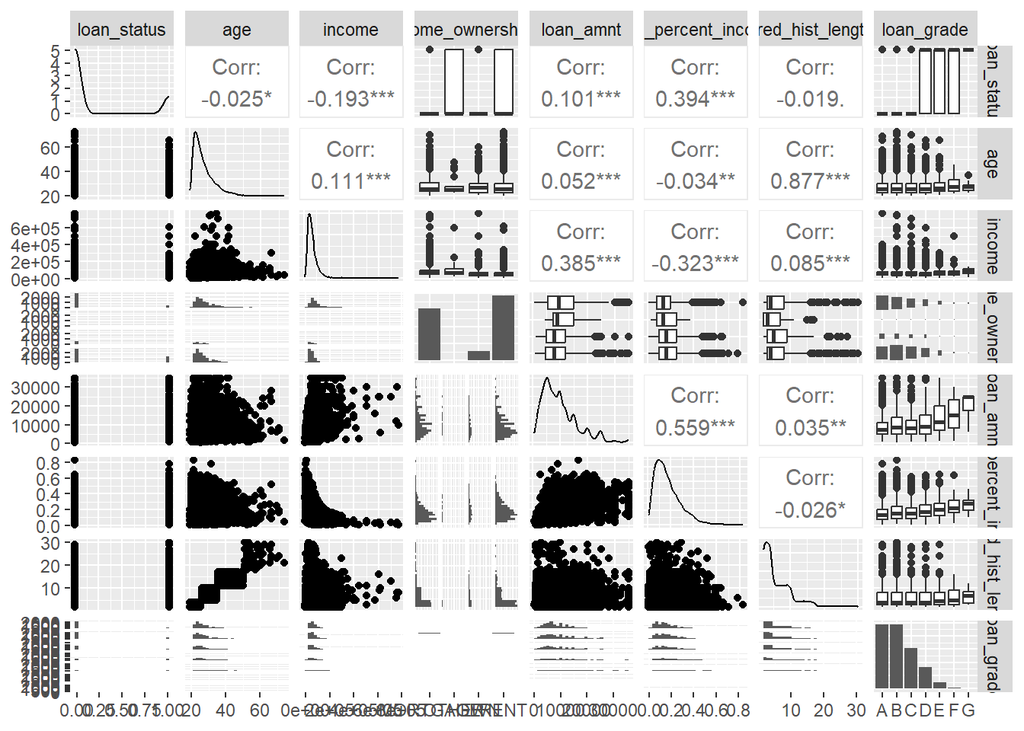

```r
  ggpairs(credit_data)
```

```r
glimpse(credit_data)
```

```
## Rows: 7,500
## Columns: 8
## $ loan_status         <dbl> 0, 0, 0, 0, 1, 0, 0, 1, 0, 0, 0, 0, 0, 0, 0, 1, 0,…
## $ age                 <dbl> 23, 24, 28, 24, 27, 24, 24, 24, 24, 23, 39, 28, 39…
## $ income              <dbl> 85000, 36000, 30996, 24000, 37440, 72000, 95000, 3…
## $ home_ownership      <chr> "MORTGAGE", "MORTGAGE", "RENT", "OWN", "RENT", "MO…
## $ loan_amnt           <dbl> 10000, 8000, 4000, 4200, 15000, 6000, 10000, 7000,…
## $ loan_percent_income <dbl> 0.12, 0.22, 0.13, 0.17, 0.40, 0.08, 0.11, 0.18, 0.…
## $ cred_hist_length    <dbl> 2, 3, 5, 3, 8, 4, 3, 4, 4, 2, 14, 5, 16, 11, 5, 13…
## $ loan_grade          <chr> "B", "B", "B", "A", "A", "A", "C", "D", "B", "B", …
```

## Some Tables

```r
credit_data |>
  group_by(loan_status) |>
  summarise(m_age = mean(age, na.rm=T),
            m_income = mean(income, na.rm=T),
            m_amount = mean(loan_amnt, na.rm=T),
            m_perc_income = mean(loan_percent_income, na.rm=T)
  )
```

```
## # A tibble: 2 × 5
##   loan_status m_age m_income m_amount m_perc_income
##         <dbl> <dbl>    <dbl>    <dbl>         <dbl>
## 1           0  27.8   70666.    9317.         0.148
## 2           1  27.4   48822.   10868.         0.251
```

```r
table(credit_data$loan_status) # shows whether borrowers repaid successfully or not
```

```
##
##    0    1
## 5903 1597
```

```r
summary(credit_data)
```

```
##   loan_status          age            income       home_ownership
##  Min.   :0.0000   Min.   :20.00   Min.   :  4200   Length:7500
##  1st Qu.:0.0000   1st Qu.:23.00   1st Qu.: 39000   Class :character
##  Median :0.0000   Median :26.00   Median : 55000   Mode  :character
##  Mean   :0.2129   Mean   :27.73   Mean   : 66015
##  3rd Qu.:0.0000   3rd Qu.:30.00   3rd Qu.: 79800
##  Max.   :1.0000   Max.   :73.00   Max.   :762000
##    loan_amnt     loan_percent_income cred_hist_length  loan_grade
##  Min.   :  500   Min.   :0.01        Min.   : 2.000   Length:7500
##  1st Qu.: 5000   1st Qu.:0.09        1st Qu.: 3.000   Class :character
##  Median : 8000   Median :0.15        Median : 4.000   Mode  :character
##  Mean   : 9647   Mean   :0.17        Mean   : 5.804
##  3rd Qu.:12250   3rd Qu.:0.23        3rd Qu.: 8.000
##  Max.   :35000   Max.   :0.83        Max.   :30.000
```

```r
table(credit_data$home_ownership) # status for home ownership
```

```
##
## MORTGAGE    OTHER      OWN     RENT
##     3067       21      566     3846
```

```r
table(credit_data$loan_intent)
```

```
## < table of extent 0 >
```

```r
table(credit_data$loan_grade) # statuses and numbers for loan grades
```

```
##
##    A    B    C    D    E    F    G
## 2437 2420 1524  824  240   44   11
```

```r
credit_data |>
  group_by(loan_status) |>
  count(home_ownership) # status of home ownership categorized by whether or not the borrowers repaid successfully or not
```

```
## # A tibble: 8 × 3
## # Groups:   loan_status [2]
##   loan_status home_ownership     n
##         <dbl> <chr>          <int>
## 1           0 MORTGAGE        2681
## 2           0 OTHER             15
## 3           0 OWN              528
## 4           0 RENT            2679
## 5           1 MORTGAGE         386
## 6           1 OTHER              6
## 7           1 OWN               38
## 8           1 RENT            1167
```

```r
# Findings: Most borrowers have successfully repaid the loan
# While, in other statuses, the rate of borrowers who repaid the loan is about the double the size of borrowers who have not repaid successfully. But in 'mortgage' it is over 6 times and in  'own' it is over 13 times
```

## Let’s Create [Some] Plot[s]

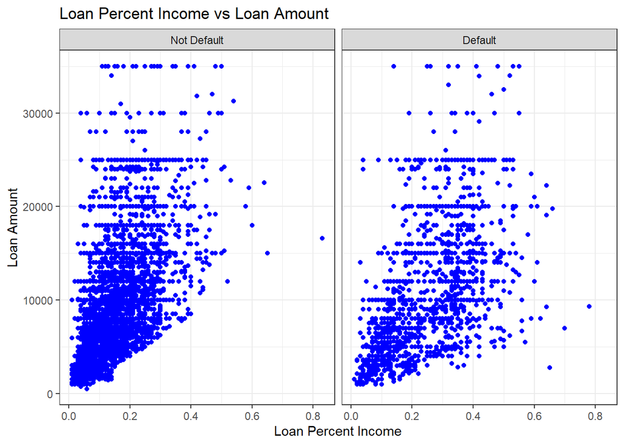

```r
credit_data |>
  ggplot(aes(loan_percent_income, loan_amnt)) +
  geom_point(color="blue") +
  facet_wrap(~ loan_status,
             labeller = as_labeller(c("0" = "Not Default", "1"="Default"))) +
  labs(
    title = "Loan Percent Income vs Loan Amount",
    x = "Loan Percent Income",
    y = "Loan Amount"
     ) +
  theme_bw()
```

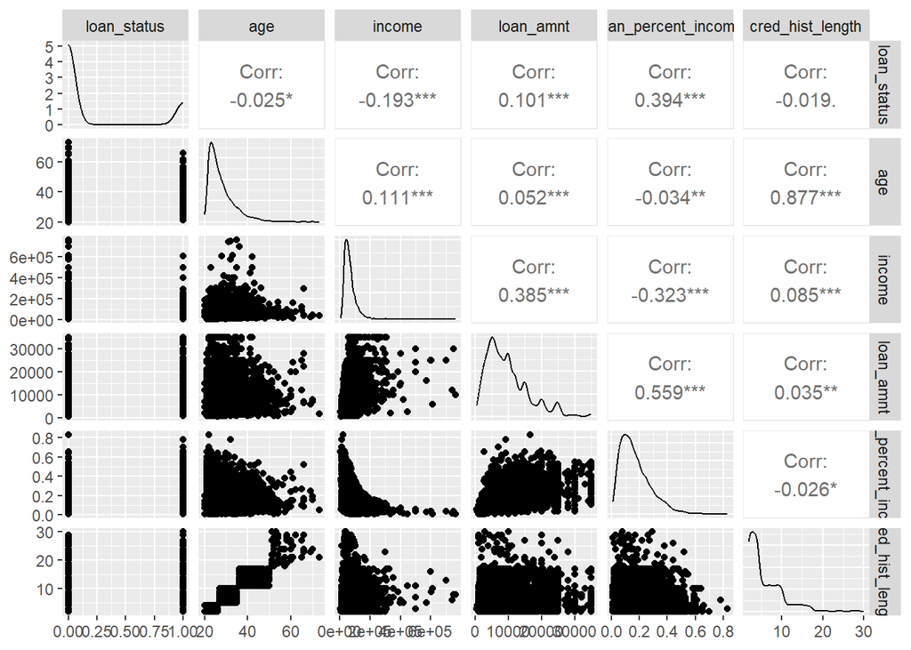

```r
credit_data |>
  select_if(is.numeric) |>
  ggpairs()
```

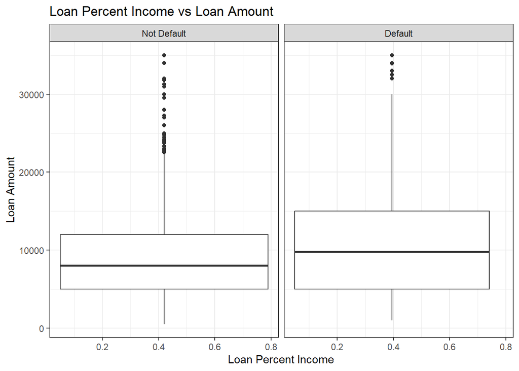

```r
# own trials (box plot of the sample)

credit_data |>
  ggplot(aes(loan_percent_income, loan_amnt)) +
  geom_boxplot() +
  facet_wrap(~ loan_status,
             labeller = as_labeller(c("0" = "Not Default", "1"="Default"))) +
  labs(
    title = "Loan Percent Income vs Loan Amount",
    x = "Loan Percent Income",
    y = "Loan Amount"
  ) +
  theme_bw()
```

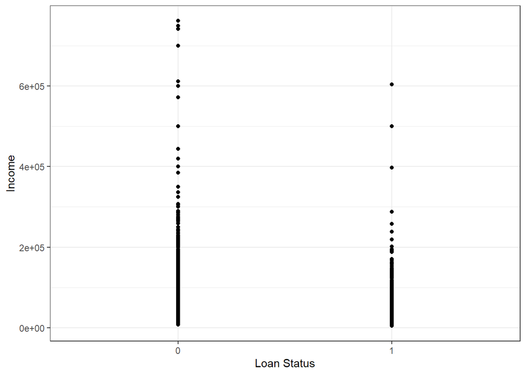

```r
# add more as you need

credit_data |>
  ggplot(aes(x = factor(loan_status), y = income)) +
  geom_point() +
  labs(
    x = "Loan Status",
    y = "Income"
  ) +
  theme_bw()
```

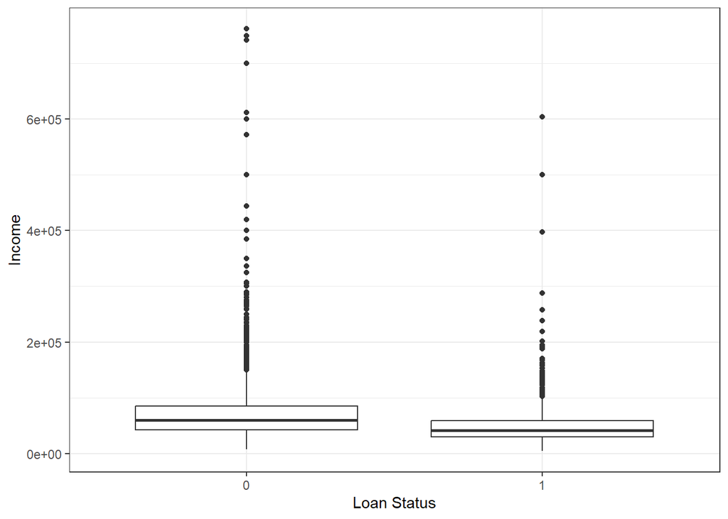

```r
#box plot

credit_data |>
  ggplot(aes(x = factor(loan_status), y = income)) +
  geom_boxplot() +
  labs(
    x = "Loan Status",
    y = "Income"
  ) +
  theme_bw()
```

## Linear Probability Model

- First Linear Model:
  - Dependent Var: loan_status
  - Independent Vars: Start with all predictors

Give a brief summary of linear model, What you see from the summary table (interpret estimations, coefficient significance etc)

```r
lm_1 <- lm(loan_status ~ loan_percent_income + cred_hist_length
           + loan_amnt + age + income + home_ownership
           + loan_grade, data=credit_data)

summary(lm_1)
```

```
##
## Call:
## lm(formula = loan_status ~ loan_percent_income + cred_hist_length +
##     loan_amnt + age + income + home_ownership + loan_grade, data = credit_data)
##
## Residuals:
##      Min       1Q   Median       3Q      Max
## -1.28651 -0.17945 -0.06280  0.05438  1.14129
##
## Coefficients:
##                       Estimate Std. Error t value Pr(>|t|)
## (Intercept)         -1.231e-01  2.960e-02  -4.157 3.26e-05 ***
## loan_percent_income  2.019e+00  6.142e-02  32.872  < 2e-16 ***
## cred_hist_length     1.122e-03  1.988e-03   0.564  0.57268
## loan_amnt           -1.825e-05  1.079e-06 -16.908  < 2e-16 ***
## age                 -6.581e-04  1.311e-03  -0.502  0.61576
## income               9.460e-07  1.268e-07   7.461 9.54e-14 ***
## home_ownershipOTHER -2.783e-02  7.259e-02  -0.383  0.70142
## home_ownershipOWN   -1.450e-01  1.535e-02  -9.448  < 2e-16 ***
## home_ownershipRENT   8.072e-02  8.535e-03   9.457  < 2e-16 ***
## loan_gradeB          2.903e-02  9.604e-03   3.022  0.00252 **
## loan_gradeC          5.069e-02  1.091e-02   4.645 3.46e-06 ***
## loan_gradeD          4.423e-01  1.350e-02  32.760  < 2e-16 ***
## loan_gradeE          4.817e-01  2.263e-02  21.285  < 2e-16 ***
## loan_gradeF          4.854e-01  5.053e-02   9.606  < 2e-16 ***
## loan_gradeG          8.654e-01  1.002e-01   8.637  < 2e-16 ***
## ---
## Signif. codes:  0 '***' 0.001 '**' 0.01 '*' 0.05 '.' 0.1 ' ' 1
##
## Residual standard error: 0.3306 on 7485 degrees of freedom
## Multiple R-squared:  0.3492, Adjusted R-squared:  0.348
## F-statistic: 286.9 on 14 and 7485 DF,  p-value: < 2.2e-16
```

- Create 2 more models containing variable transformation. Get the summary tables, interpret them
- Select the best model among them, explain your reasoning

```r
lm_2 <- lm(loan_status ~ log(income), data=credit_data)

names(lm_2)
```

```
##  [1] "coefficients"  "residuals"     "effects"       "rank"
##  [5] "fitted.values" "assign"        "qr"            "df.residual"
##  [9] "xlevels"       "call"          "terms"         "model"
```

```r
summary(lm_2)
```

```
##
## Call:
## lm(formula = loan_status ~ log(income), data = credit_data)
##
## Residuals:
##      Min       1Q   Median       3Q      Max
## -0.62878 -0.24596 -0.15991 -0.00414  1.29149
##
## Coefficients:
##              Estimate Std. Error t value Pr(>|t|)
## (Intercept)  2.533574   0.089043   28.45   <2e-16 ***
## log(income) -0.212230   0.008133  -26.10   <2e-16 ***
## ---
## Signif. codes:  0 '***' 0.001 '**' 0.01 '*' 0.05 '.' 0.1 ' ' 1
##
## Residual standard error: 0.392 on 7498 degrees of freedom
## Multiple R-squared:  0.08326,    Adjusted R-squared:  0.08314
## F-statistic:   681 on 1 and 7498 DF,  p-value: < 2.2e-16
```

```r
lm_3 <- lm(loan_status ~ income + I(income^2) + loan_amnt
           + home_ownership, data=credit_data)

names(lm_3)
```

```
##  [1] "coefficients"  "residuals"     "effects"       "rank"
##  [5] "fitted.values" "assign"        "qr"            "df.residual"
##  [9] "contrasts"     "xlevels"       "call"          "terms"
## [13] "model"
```

```r
summary(lm_3)
```

```
##
## Call:
## lm(formula = loan_status ~ income + I(income^2) + loan_amnt +
##     home_ownership, data = credit_data)
##
## Residuals:
##      Min       1Q   Median       3Q      Max
## -1.25661 -0.26748 -0.14475  0.08653  1.32323
##
## Coefficients:
##                       Estimate Std. Error t value Pr(>|t|)
## (Intercept)          2.721e-01  1.376e-02  19.765  < 2e-16 ***
## income              -4.764e-06  1.927e-07 -24.722  < 2e-16 ***
## I(income^2)          7.235e-12  4.287e-13  16.873  < 2e-16 ***
## loan_amnt            1.627e-05  7.725e-07  21.059  < 2e-16 ***
## home_ownershipOTHER  1.484e-01  8.307e-02   1.787    0.074 .
## home_ownershipOWN   -1.116e-01  1.758e-02  -6.351 2.27e-10 ***
## home_ownershipRENT   1.158e-01  9.712e-03  11.926  < 2e-16 ***
## ---
## Signif. codes:  0 '***' 0.001 '**' 0.01 '*' 0.05 '.' 0.1 ' ' 1
##
## Residual standard error: 0.3789 on 7493 degrees of freedom
## Multiple R-squared:  0.1442, Adjusted R-squared:  0.1435
## F-statistic: 210.3 on 6 and 7493 DF,  p-value: < 2.2e-16
```

## Logistic Regression

- First Logistic Model:
  - Dependent Var: loan_status
  - Independent Vars: Start with all predictors

Give a brief summary of linear model, What you see from the summary table (interpret estimations, coefficient significance etc)

```r
# estimate a Logit regression with multiple regressors
logit_1 <- glm(loan_status ~ loan_percent_income + cred_hist_length
           + loan_amnt + age + income + home_ownership
           + loan_grade,
                  family = binomial(link = "logit"),
                  data = credit_data)

summary(logit_1)
```

```
##
## Call:
## glm(formula = loan_status ~ loan_percent_income + cred_hist_length +
##     loan_amnt + age + income + home_ownership + loan_grade, family = binomial(link = "logit"),
##     data = credit_data)
##
## Coefficients:
##                       Estimate Std. Error z value Pr(>|z|)
## (Intercept)         -4.068e+00  2.906e-01 -14.000  < 2e-16 ***
## loan_percent_income  1.396e+01  6.164e-01  22.656  < 2e-16 ***
## cred_hist_length     1.137e-02  1.865e-02   0.610 0.542143
## loan_amnt           -1.236e-04  1.093e-05 -11.305  < 2e-16 ***
## age                 -7.721e-03  1.226e-02  -0.630 0.528679
## income               3.695e-06  1.506e-06   2.454 0.014126 *
## home_ownershipOTHER -1.085e-01  6.261e-01  -0.173 0.862383
## home_ownershipOWN   -1.925e+00  2.203e-01  -8.740  < 2e-16 ***
## home_ownershipRENT   7.054e-01  8.213e-02   8.589  < 2e-16 ***
## loan_gradeB          3.639e-01  1.006e-01   3.617 0.000298 ***
## loan_gradeC          5.773e-01  1.085e-01   5.322 1.03e-07 ***
## loan_gradeD          2.926e+00  1.160e-01  25.221  < 2e-16 ***
## loan_gradeE          3.141e+00  1.788e-01  17.567  < 2e-16 ***
## loan_gradeF          3.208e+00  3.836e-01   8.361  < 2e-16 ***
## loan_gradeG          1.757e+01  2.322e+02   0.076 0.939703
## ---
## Signif. codes:  0 '***' 0.001 '**' 0.01 '*' 0.05 '.' 0.1 ' ' 1
##
## (Dispersion parameter for binomial family taken to be 1)
##
##     Null deviance: 7767.3  on 7499  degrees of freedom
## Residual deviance: 5122.6  on 7485  degrees of freedom
## AIC: 5152.6
##
## Number of Fisher Scoring iterations: 13
```

## Decision Tree

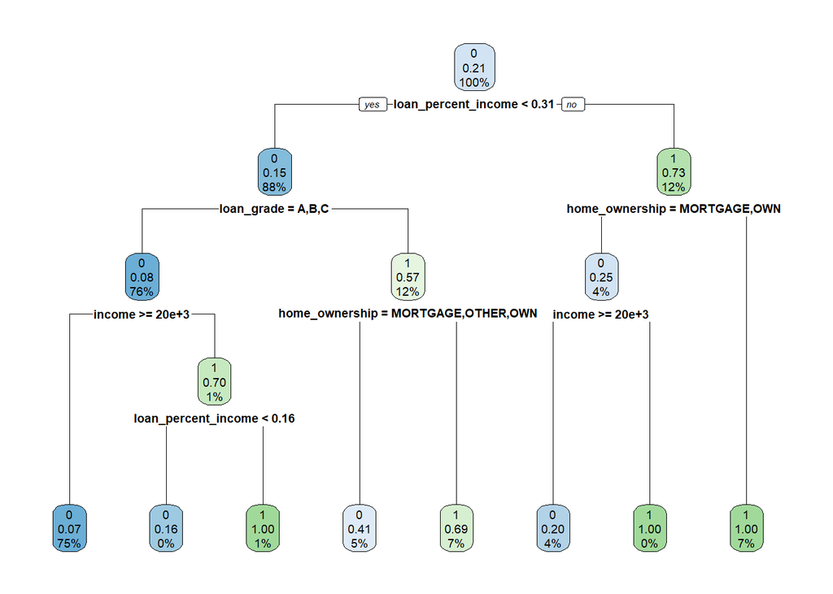

```r
tree_model <- rpart(
  loan_status ~ loan_percent_income + cred_hist_length
           + loan_amnt + age + income + home_ownership
           + loan_grade,
  data = credit_data,
  method = "class"
)

rpart.plot(tree_model)
```

```r
tree_model$variable.importance
```

```
## loan_percent_income          loan_grade      home_ownership              income
##          559.534307          387.485752          257.413974          143.067842
##           loan_amnt                 age
##           57.688922            1.159577
```